# college Data Science Project

Maziyar Bahri

12/7/2021

Load Package to Library, These Libraries we need for our deploying ML

```r
library("moments")
library("ggplot2")
library("MASS")
library("leaps")
library("corrplot")
library("carData")
library("car")
library("corrplot")
library("glmnet")
library("randomForest")
library("leaps")
library("rpart")
library("rpart.plot")
library("gbm")
library("xgboost")
library("Metrics")
```

Loading dataset from

```r
dataRaw<- read.csv("../college.csv", header = TRUE)
```

# Data Science Project College

# Business understanding

## 1. What is the main motivation of College data set?

This data set had been published by U.S. News and World Report in September of 1995. This Data set has helped students and parents to narrow their choices and choose a decent college. This data set is included some features of the college (Private, Location, number of facilities, Rate of a student, acceptance rate, grade and etc. However, The Book cost and other potential expenses are mentioned in this data set, which gives a wide point of view to us for considering the expense in this study as one of an important element.

## 2&3.What might the output of this project be used?Who might be interested in the results of this project? Why?

This project has been assumed to predict the number of applications received. Then with an estimation of application volume, we could predict each college how many applications would be received each year. Then students are able to use this project to find a popular college or high-demand schools. on the other side, colleges are able to use this model in another way, college could use this model to find out other rival colleges how many applicants they have, and compare themself with other colleges, or they can adjust their system to rate of applications, for instance, if they are receiving a lot of application they can hire more recruiter for checking the applicants or if they are not high demanded college they can take another measurement to receive more.

# Data Description

## 1. Where is the data obtained and how is it collected?

This data set was taken from the StatLib library which is maintained at Carnegie Mellon University. The dataset was used in the ASA Statistical Graphics Section’s 1995 Data Analysis Exposition. https://rdrr.io/cran/ISLR/man/College.html

## 2. What do each of the variables measure?

The the column of data are:

```r
print(colnames(dataRaw))
```

```
##  [1] "College.Name" "Private"      "Apps"         "Accept"       "Enroll"
##  [6] "Top10perc"    "Top25perc"    "F.Undergrad"  "P.Undergrad"  "Outstate"
## [11] "Room.Board"   "Books"        "Personal"     "PhD"          "Terminal"
## [16] "S.F.Ratio"    "perc.alumni"  "Expend"       "Grad.Rate"
```

College data frame with 777 observations on the following 18 variables.

**Private** – This feature shows the college is private or Not.  
**Apps** – The number of applications that were received by the college.  
**Accept** – The number of **applications accepted** by the college.  
**Enroll** – The number of new students were enrolled in that college in 1995.  
**Top10perc** – The percent of new students who had been from the top **10%** of **previous High school** class.  
**Top25perc** – The percent of new students who had been from the top **25%** of **previous High school** class.  
**F.Undergrad** – Number of **full-time undergraduates** who had studied at those colleges.  
**P.Undergrad** – Number of **part-time undergraduates** who had studied at those colleges.  
**Outstate** – Out-of-state tuition refers to the amount of money the student from **another state** wants to attend at another college from another state.  
**Room.Board** – Lodging and food **expenses** for students.  
**Books** – Estimated **book costs** that students had to pay.  
**Personal** – Estimated **personal spending** for student daily life.  
**PhD** – Percent of faculty who had **Ph.D.’s.**  
**Terminal** – Percent of faculty who had **terminal** degree.  
**S.F.Ratio** – Ratio of Student per faculty.  
**perc.alumni** – Percent of alumni who **donated money** after their graduation, this key shows that college was useful for students who are already graduated.  
**Expend** – Instructional expenditure per student which college has to allocate for student.  
**Grad.Rate** – Graduation rate for each college.

## 4. Is there an error in measuring variables or recording data?

I did not find any issues.

## 5. What other variables, could help solve the problem?

Founded date can be useful because sometime the rate for applicants, would be more than a new college.

## 6. What kind of variables are there (Categorical - Numerical)?

College.Name, Private are Categorical and rest of feature are Numerical, However in the following I would be removed college.Name for reducing the Biased risk. Also, Private is Boolean type, which I changed it with Factor

```r
str(dataRaw)
```

```
## 'data.frame':    777 obs. of  19 variables:
##  $ College.Name: chr  "Abilene Christian University" "Adelphi University" "Adrian College" "Agnes Scott College" ...
##  $ Private     : chr  "Yes" "Yes" "Yes" "Yes" ...
##  $ Apps        : int  1660 2186 1428 417 193 587 353 1899 1038 582 ...
##  $ Accept      : int  1232 1924 1097 349 146 479 340 1720 839 498 ...
##  $ Enroll      : int  721 512 336 137 55 158 103 489 227 172 ...
##  $ Top10perc   : int  23 16 22 60 16 38 17 37 30 21 ...
##  $ Top25perc   : int  52 29 50 89 44 62 45 68 63 44 ...
##  $ F.Undergrad : int  2885 2683 1036 510 249 678 416 1594 973 799 ...
##  $ P.Undergrad : int  537 1227 99 63 869 41 230 32 306 78 ...
##  $ Outstate    : int  7440 12280 11250 12960 7560 13500 13290 13868 15595 10468 ...
##  $ Room.Board  : int  3300 6450 3750 5450 4120 3335 5720 4826 4400 3380 ...
##  $ Books       : int  450 750 400 450 800 500 500 450 300 660 ...
##  $ Personal    : int  2200 1500 1165 875 1500 675 1500 850 500 1800 ...
##  $ PhD         : int  70 29 53 92 76 67 90 89 79 40 ...
##  $ Terminal    : int  78 30 66 97 72 73 93 100 84 41 ...
##  $ S.F.Ratio   : num  18.1 12.2 12.9 7.7 11.9 9.4 11.5 13.7 11.3 11.5 ...
##  $ perc.alumni : int  12 16 30 37 2 11 26 37 23 15 ...
##  $ Expend      : int  7041 10527 8735 19016 10922 9727 8861 11487 11644 8991 ...
##  $ Grad.Rate   : int  60 56 54 59 15 55 63 73 80 52 ...
```

In here we want to remove **college Name** and change **Private** to Factor:

```r
#Remove College.Name
length(unique(dataRaw$College.Name))
```

```
## [1] 777
```

```r
data <- dataRaw[,-1]

##Uni variate Profiling
length(unique(data$Private))
```

```
## [1] 2
```

```r
unique(data$Private)
```

```
## [1] "Yes" "No"
```

```r
data$Private <- factor(data$Private)
summary(data)
```

```
##  Private        Apps           Accept          Enroll       Top10perc
##  No :212   Min.   :   81   Min.   :   72   Min.   :  35   Min.   : 1.00
##  Yes:565   1st Qu.:  776   1st Qu.:  604   1st Qu.: 242   1st Qu.:15.00
##            Median : 1558   Median : 1110   Median : 434   Median :23.00
##            Mean   : 3002   Mean   : 2019   Mean   : 780   Mean   :27.56
##            3rd Qu.: 3624   3rd Qu.: 2424   3rd Qu.: 902   3rd Qu.:35.00
##            Max.   :48094   Max.   :26330   Max.   :6392   Max.   :96.00
##    Top25perc      F.Undergrad     P.Undergrad         Outstate
##  Min.   :  9.0   Min.   :  139   Min.   :    1.0   Min.   : 2340
##  1st Qu.: 41.0   1st Qu.:  992   1st Qu.:   95.0   1st Qu.: 7320
##  Median : 54.0   Median : 1707   Median :  353.0   Median : 9990
##  Mean   : 55.8   Mean   : 3700   Mean   :  855.3   Mean   :10441
##  3rd Qu.: 69.0   3rd Qu.: 4005   3rd Qu.:  967.0   3rd Qu.:12925
##  Max.   :100.0   Max.   :31643   Max.   :21836.0   Max.   :21700
##    Room.Board       Books           Personal         PhD
##  Min.   :1780   Min.   :  96.0   Min.   : 250   Min.   :  8.00
##  1st Qu.:3597   1st Qu.: 470.0   1st Qu.: 850   1st Qu.: 62.00
##  Median :4200   Median : 500.0   Median :1200   Median : 75.00
##  Mean   :4358   Mean   : 549.4   Mean   :1341   Mean   : 72.66
##  3rd Qu.:5050   3rd Qu.: 600.0   3rd Qu.:1700   3rd Qu.: 85.00
##  Max.   :8124   Max.   :2340.0   Max.   :6800   Max.   :103.00
##     Terminal       S.F.Ratio      perc.alumni        Expend
##  Min.   : 24.0   Min.   : 2.50   Min.   : 0.00   Min.   : 3186
##  1st Qu.: 71.0   1st Qu.:11.50   1st Qu.:13.00   1st Qu.: 6751
##  Median : 82.0   Median :13.60   Median :21.00   Median : 8377
##  Mean   : 79.7   Mean   :14.09   Mean   :22.74   Mean   : 9660
##  3rd Qu.: 92.0   3rd Qu.:16.50   3rd Qu.:31.00   3rd Qu.:10830
##  Max.   :100.0   Max.   :39.80   Max.   :64.00   Max.   :56233
##    Grad.Rate
##  Min.   : 10.00
##  1st Qu.: 53.00
##  Median : 65.00
##  Mean   : 65.46
##  3rd Qu.: 78.00
##  Max.   :118.00
```

# Data preprocesing

## 1,2,3 and 4. Data Manipulation and Data cleaning

The college name has already been removed, Because the name of the college could be affected by the decision, for instance, if sometimes name of a specific college could change students point of view students point of view

```r
data <- dataRaw[,-1]
```

# Data Visualization

## Categorical variables

we want to check Categorical data, and here we can see, they are **not distributed** same

```r
#Categorical variables
table(data$Private)
```

```
##
##  No Yes
## 212 565
```

we have 212 **non-private** School and 565 **private** school

## Numerical variables

**Note:** In here you can see the distribution of Numerical varible.

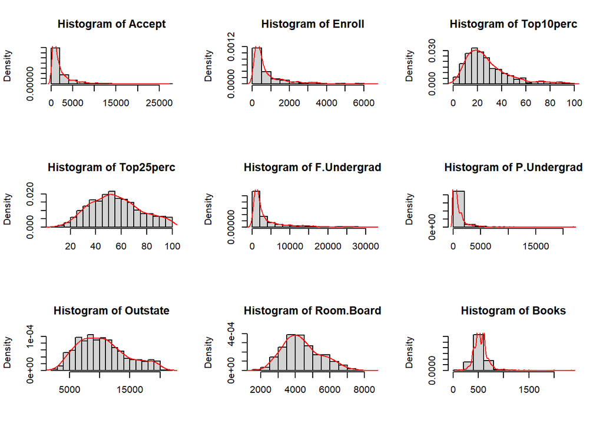

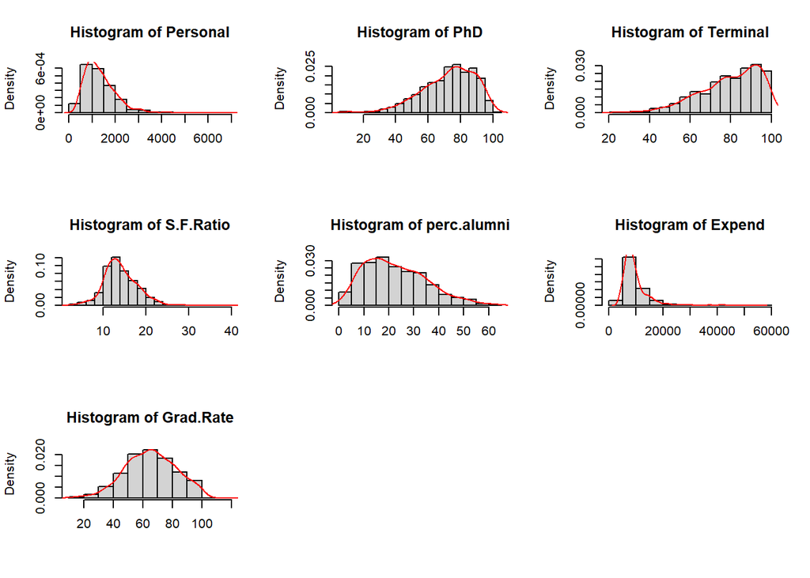

```r
#distribution
par(mfrow = c(3, 3))  # 4 rows and 4 columns
#Continuous variables distribution
for (i in 3:18) {
  hist(data[, i], xlab = "",  probability = T, breaks = 15,
       main = paste("Histogram of", names(data)[i]))
  lines(density(data[,i]), col = "red")
}
```

**QQ Plot** shows data are distributed Normal distribution or they are not Normal

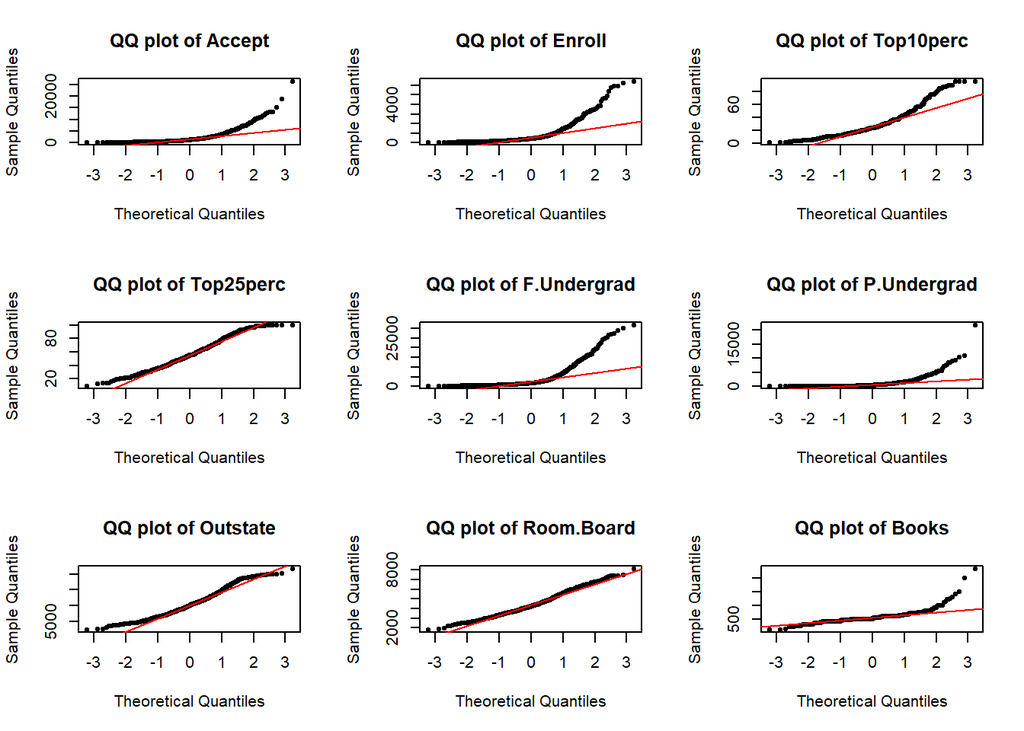

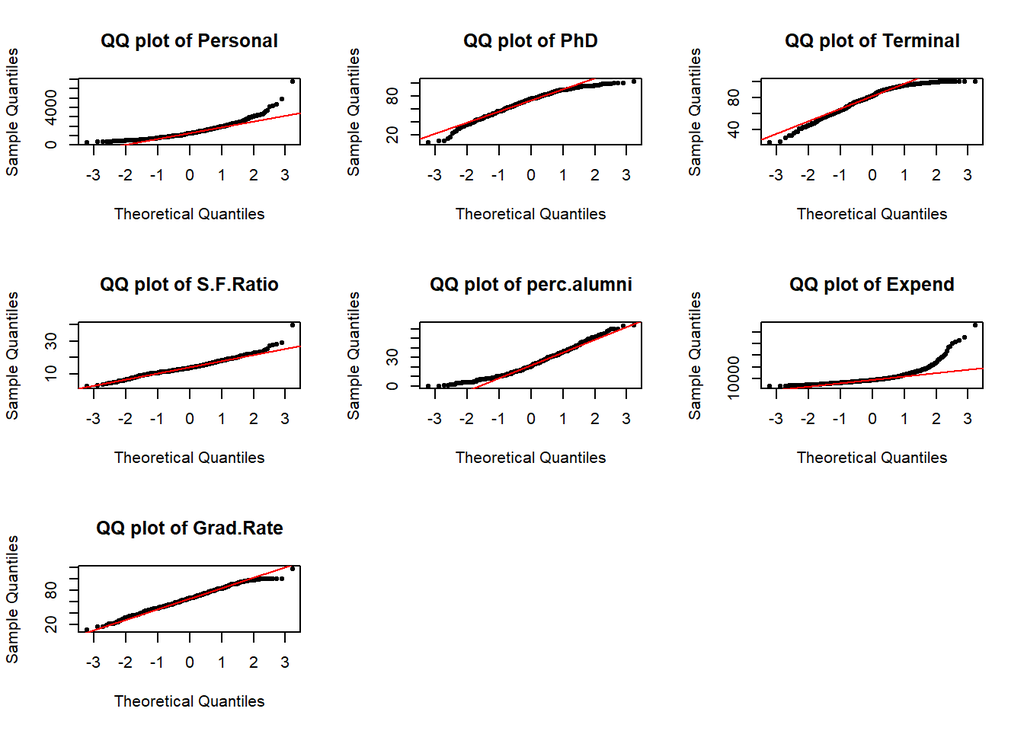

```r
par(mfrow = c(3, 3))
for (i in 3:18) {
  qqnorm(data[,i], main = paste("QQ plot of", names(data)[i]), pch = 20)
  qqline(data[,i], col = "red")
}
```

**Note:** From **QQ plot** we can see data are **not distributed Normal** and we may have some issues in developing models.

Scatter Plot shows data are distributed liner or not

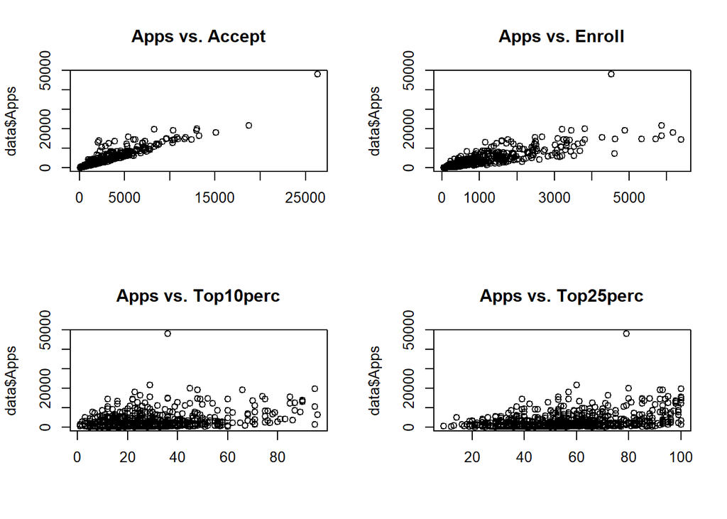

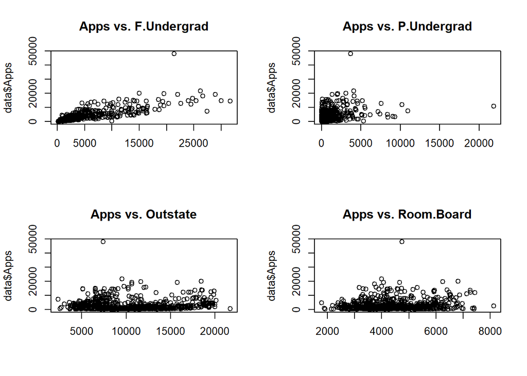

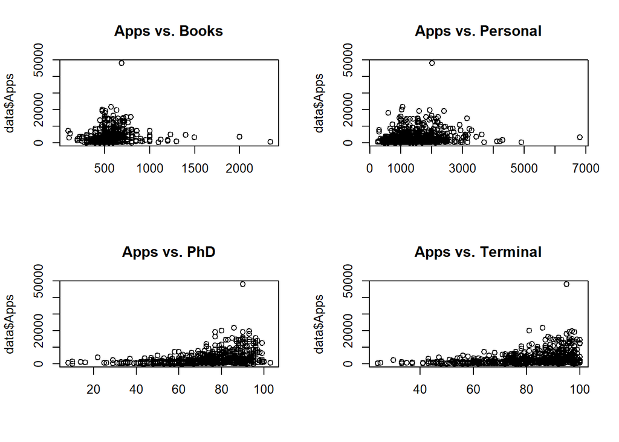

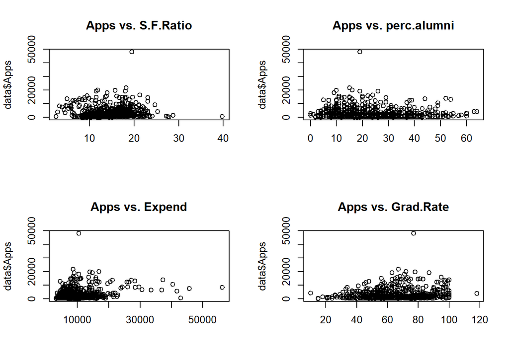

```r
#Scatter Plot
par(mfrow = c(2, 2))  # 2 rows and 2 columns
for (i in 3:18) {
  plot(data[,i], data$Apps, xlab = "", main = paste("Apps vs.", names(data)[i]))
}
```

**Note:** From this plot is is obvious **Book** vs **Apps** does not have any liner relation.

A visualization of a **correlation matrix**, it is illustrated some features are correlated to each other

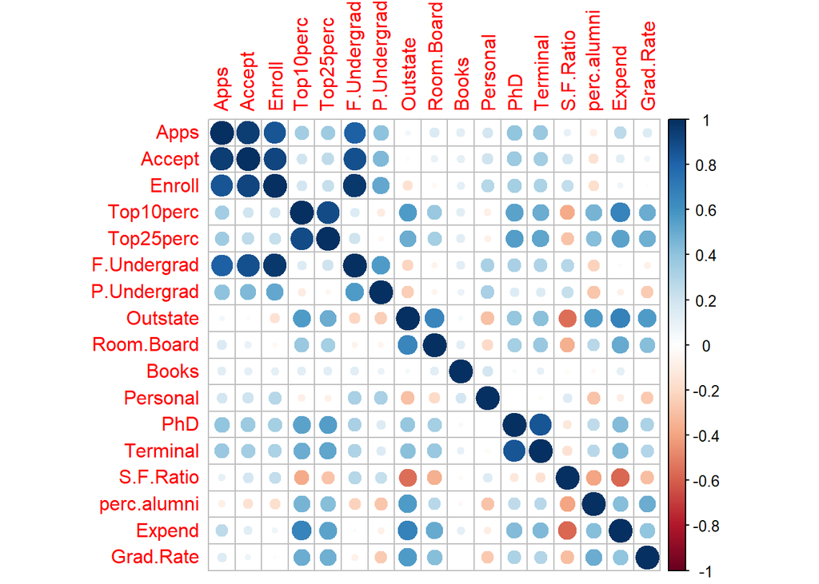

```r
cor_table <- round(cor(data[, c(2: 18)]), 2)
corrplot(cor_table)
```

We can see **OutSate** and **Expend** are having a great relation with each other. Also,**Expend** vs **Top10perc**, **Enrol** vs **F.Undergraduate** and **Enroll** vs **Accept**. So, without a doubt we will face **multicollinearity**.

## Identify Outliers

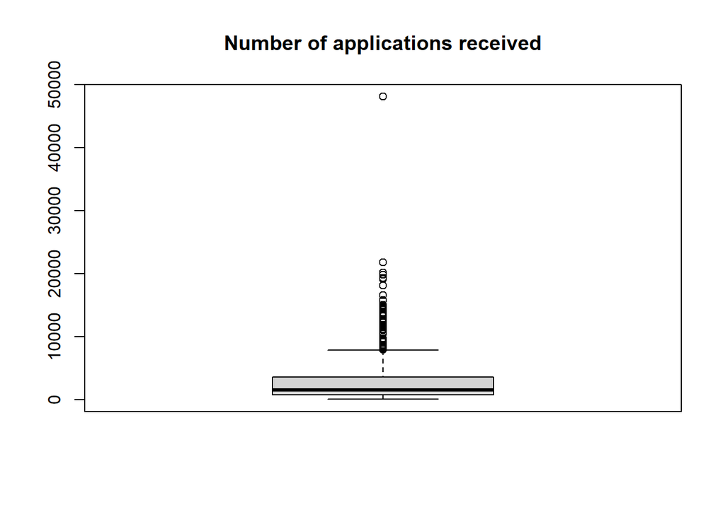

```r
boxplot(data$Apps, main = "Number of applications received")
```

**Note:** We can see we have some outliers in **Apps**

```r
tukey_ul <- quantile(data$Apps, probs = 0.75) + 1.5 * IQR(data$Apps)
tukey_ul
```

```
##  75%
## 7896
```

```r
sum(data$Apps > tukey_ul)
```

```
## [1] 70
```

```r
sum(data$Apps > tukey_ul)/nrow(data) * 100
```

```
## [1] 9.009009
```

**Note:** It shows **9%** of data are located in **outliers**, and **70** of our observation are **outliers**.

# Developing Machine learning

Because we do not have enough data to study I assume **80-20** for **train** and **test**.

```r
set.seed(1234)
train_cases <- sample(1:nrow(data), nrow(data) * 0.8)
train <- data[train_cases,]
test  <- data[- train_cases,]
```

So, **621** observation are selected for train and **156** for test.

With the following method I check data are distributed appropriately and they are balance.  
This part I added for optional and for saving more space in Markdown **I did not Run** it Again.

```r
#for (i in 2:18){
#  print(colnames(train[i]))
#  print("***** train *****")
#  print(summary(train[, i]))
#  print("***** test ***** ")
#  print(summary(test[, i]))
#  print("----------------------")
#}
```

Looks fine now data are separated balance in Test and train.

## Linear Regression

I developed some single regression, to obtain a general knowledge on the dataset, for having better Markdown I remove them

### Model 1 Simple Regression

#### Model 1-1 All feature

This is first attempt and in here we are going to have general idea about data, and assign regression on all.

```r
mAll <-lm(Apps ~., data = train) # R-squared:  0.9301
summary(mAll)
```

```
##
## Call:
## lm(formula = Apps ~ ., data = train)
##
## Residuals:
##     Min      1Q  Median      3Q     Max
## -4986.3  -437.5   -27.5   349.3  7477.7
##
## Coefficients:
##               Estimate Std. Error t value Pr(>|t|)
## (Intercept) -269.37441  470.65134  -0.572 0.567302
## PrivateYes  -556.92666  158.98705  -3.503 0.000494 ***
## Accept         1.61251    0.04522  35.663  < 2e-16 ***
## Enroll        -1.00895    0.20558  -4.908 1.19e-06 ***
## Top10perc     51.58116    6.28296   8.210 1.35e-15 ***
## Top25perc    -12.71458    5.07264  -2.507 0.012455 *
## F.Undergrad    0.06699    0.03506   1.911 0.056481 .
## P.Undergrad    0.05459    0.03664   1.490 0.136754
## Outstate      -0.07734    0.02168  -3.567 0.000390 ***
## Room.Board     0.14503    0.05434   2.669 0.007816 **
## Books         -0.05186    0.26079  -0.199 0.842454
## Personal       0.03539    0.07218   0.490 0.624099
## PhD           -8.83817    5.22973  -1.690 0.091547 .
## Terminal      -3.69562    5.72493  -0.646 0.518829
## S.F.Ratio      6.47534   14.94182   0.433 0.664901
## perc.alumni   -2.17844    4.76019  -0.458 0.647378
## Expend         0.06270    0.01385   4.525 7.27e-06 ***
## Grad.Rate      9.79422    3.46427   2.827 0.004851 **
## ---
## Signif. codes:  0 '***' 0.001 '**' 0.01 '*' 0.05 '.' 0.1 ' ' 1
##
## Residual standard error: 1065 on 603 degrees of freedom
## Multiple R-squared:  0.9301, Adjusted R-squared:  0.9282
## F-statistic: 472.3 on 17 and 603 DF,  p-value: < 2.2e-16
```

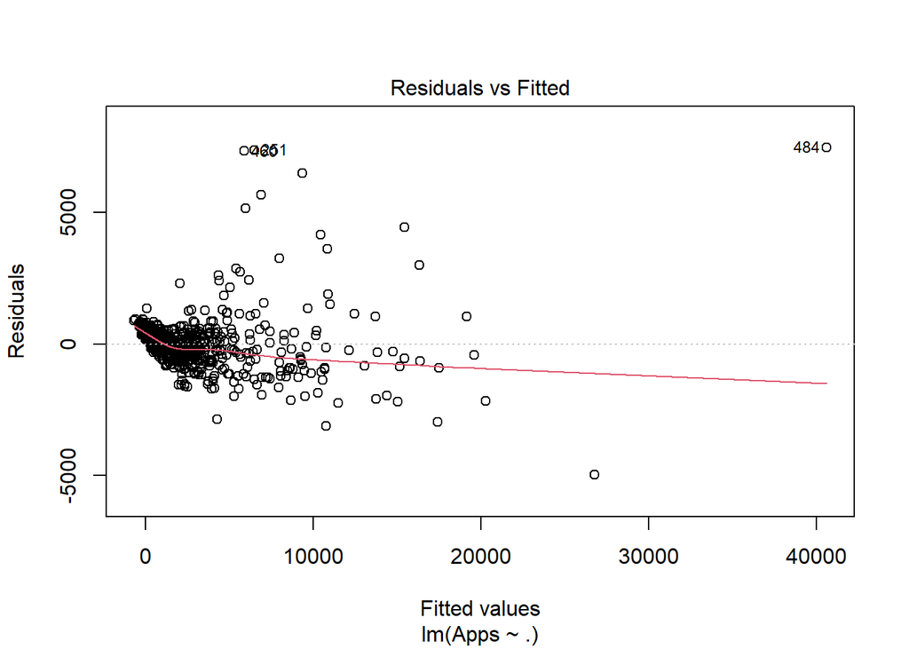

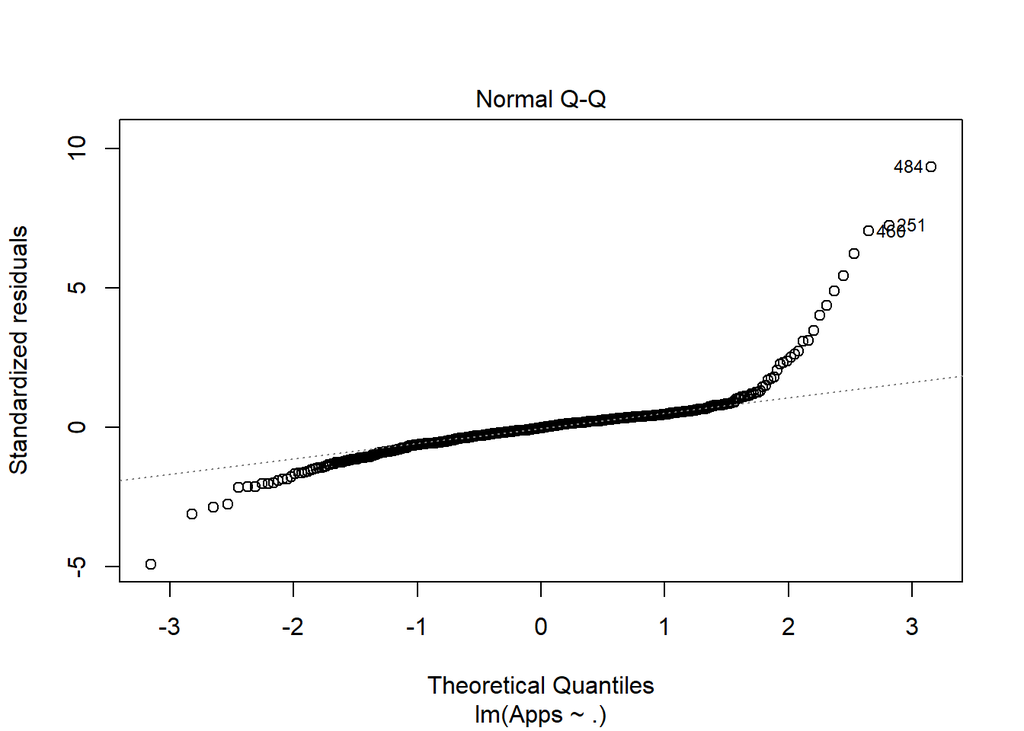

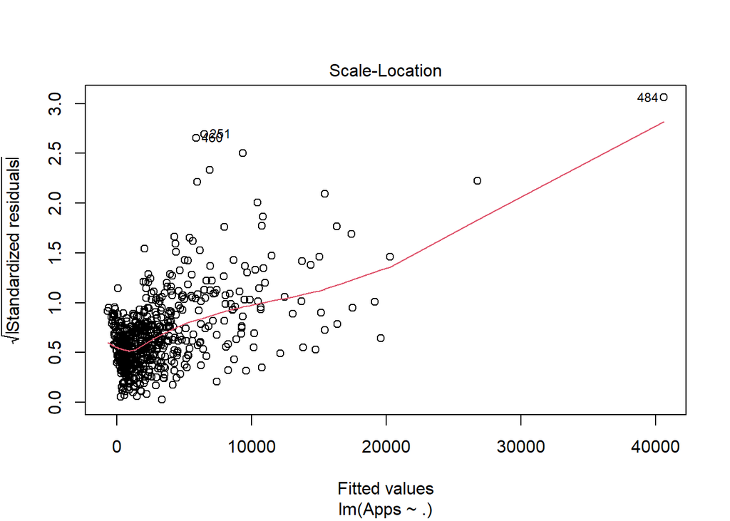

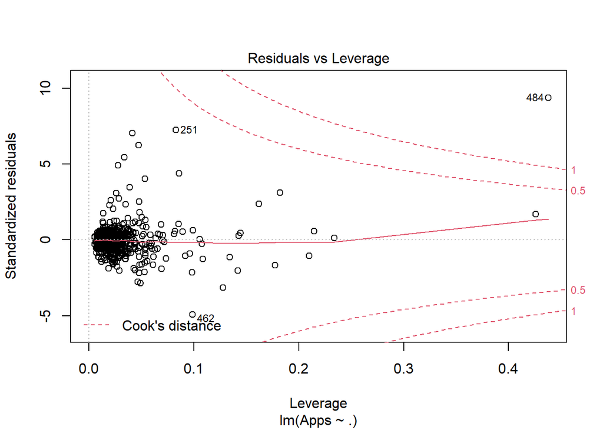

```r
plot(mAll)
```

We can see data are not Normal, and Residual plot has some relation ….  
But we can see observation of 484 is located in cook distance, so we should do more resach on this dataset.

```r
car :: vif(mAll)
```

```
##     Private      Accept      Enroll   Top10perc   Top25perc F.Undergrad
##    2.743057    7.096926   20.101547    6.644524    5.517248   16.232478
## P.Undergrad    Outstate  Room.Board       Books    Personal         PhD
##    1.759914    4.161178    1.934227    1.111069    1.304506    3.905554
##    Terminal   S.F.Ratio perc.alumni      Expend   Grad.Rate
##    3.854981    1.857082    1.928993    2.819537    1.888305
```

**Note**: F.Undergrad and Enroll have Multicollinearity, because they are more than 10

```r
dataRaw[484,]
```

```
##                 College.Name Private  Apps Accept Enroll Top10perc Top25perc
## 484 Rutgers at New Brunswick      No 48094  26330   4520        36        79
##     F.Undergrad P.Undergrad Outstate Room.Board Books Personal PhD Terminal
## 484       21401        3712     7410       4748   690     2009  90       95
##     S.F.Ratio perc.alumni Expend Grad.Rate
## 484      19.5          19  10474        77
```

```r
train[71,]
```

```
##    Private  Apps Accept Enroll Top10perc Top25perc F.Undergrad P.Undergrad
## 71     Yes 12586   3239   1462        87        95        5643         349
##    Outstate Room.Board Books Personal PhD Terminal S.F.Ratio perc.alumni Expend
## 71    19528       5926   720     1100  99      100       7.6          39  20440
##    Grad.Rate
## 71        97
```

```r
train[251,]
```

```
##     Private Apps Accept Enroll Top10perc Top25perc F.Undergrad P.Undergrad
## 344     Yes 4731   3171    830        12        31        3557         658
##     Outstate Room.Board Books Personal PhD Terminal S.F.Ratio perc.alumni
## 344    10700       5925   550     1200  74       81      17.6          34
##     Expend Grad.Rate
## 344   8408        69
```

```r
train2 <- train[- which(rownames(train) %in% c(484, 251, 71, 694)), ]
```

Based on my assumption, I will work with **train2** Since now. for rest of works.  
**Note**: I have to mention that, in my draft file I developed ML for **train1** and **train2**, and I have found that **train2** works better on test and train. Because of lacking space in Markdown I did not mention them here.

```r
mAllRemoved <-lm(Apps ~., data = train2)
summary(mAllRemoved)
```

```
##
## Call:
## lm(formula = Apps ~ ., data = train2)
##
## Residuals:
##     Min      1Q  Median      3Q     Max
## -3197.7  -409.1   -37.8   299.5  7747.8
##
## Coefficients:
##               Estimate Std. Error t value Pr(>|t|)
## (Intercept) -4.796e+02  3.892e+02  -1.232 0.218328
## PrivateYes  -5.523e+02  1.312e+02  -4.210 2.95e-05 ***
## Accept       1.334e+00  4.898e-02  27.243  < 2e-16 ***
## Enroll      -6.032e-01  1.807e-01  -3.339 0.000894 ***
## Top10perc    3.833e+01  5.232e+00   7.327 7.66e-13 ***
## Top25perc   -6.871e+00  4.188e+00  -1.641 0.101385
## F.Undergrad  1.037e-01  2.887e-02   3.592 0.000355 ***
## P.Undergrad  5.112e-02  3.014e-02   1.696 0.090419 .
## Outstate    -3.805e-02  1.821e-02  -2.089 0.037094 *
## Room.Board   1.705e-01  4.477e-02   3.809 0.000154 ***
## Books       -3.361e-02  2.144e-01  -0.157 0.875474
## Personal    -8.611e-03  5.942e-02  -0.145 0.884823
## PhD         -7.749e+00  4.292e+00  -1.806 0.071489 .
## Terminal    -2.796e+00  4.699e+00  -0.595 0.552087
## S.F.Ratio    3.520e+00  1.236e+01   0.285 0.775871
## perc.alumni -7.434e+00  3.968e+00  -1.873 0.061501 .
## Expend       5.094e-02  1.162e-02   4.384 1.37e-05 ***
## Grad.Rate    9.154e+00  2.857e+00   3.204 0.001425 **
## ---
## Signif. codes:  0 '***' 0.001 '**' 0.01 '*' 0.05 '.' 0.1 ' ' 1
##
## Residual standard error: 873.5 on 599 degrees of freedom
## Multiple R-squared:  0.938,  Adjusted R-squared:  0.9363
## F-statistic: 533.3 on 17 and 599 DF,  p-value: < 2.2e-16
```

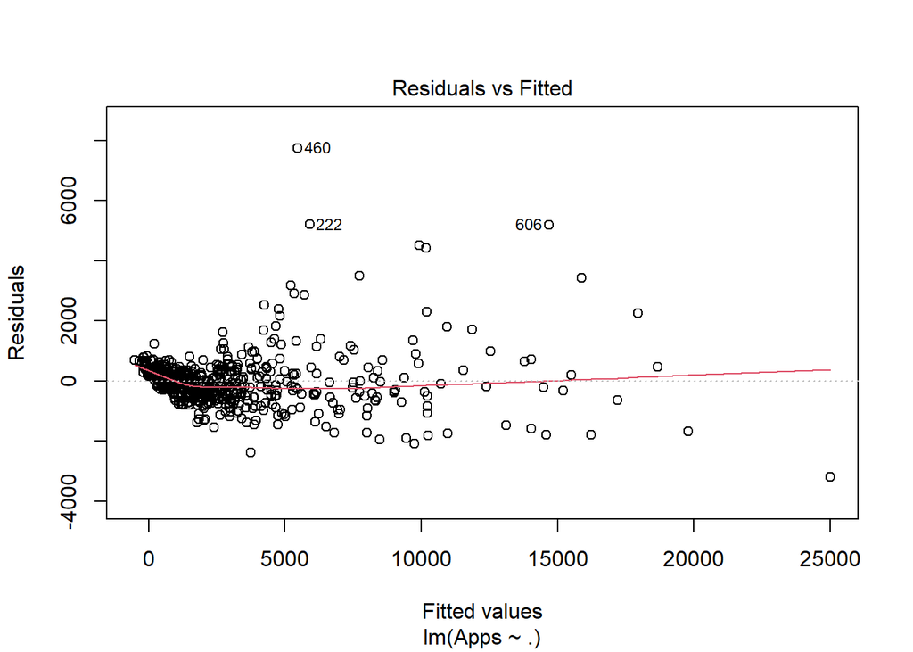

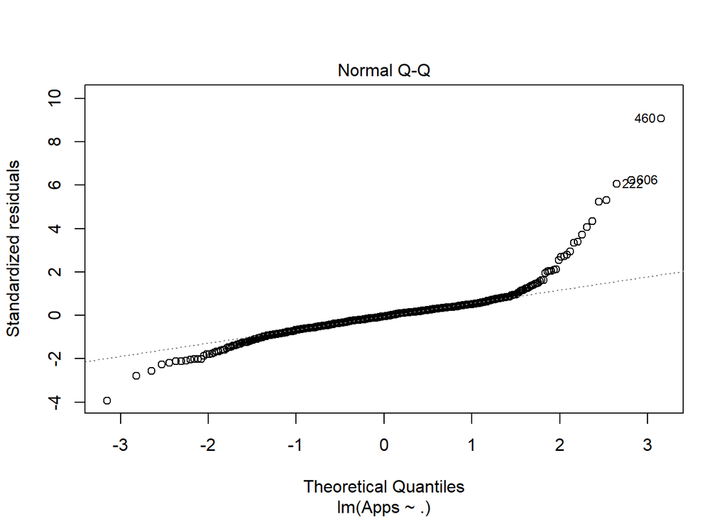

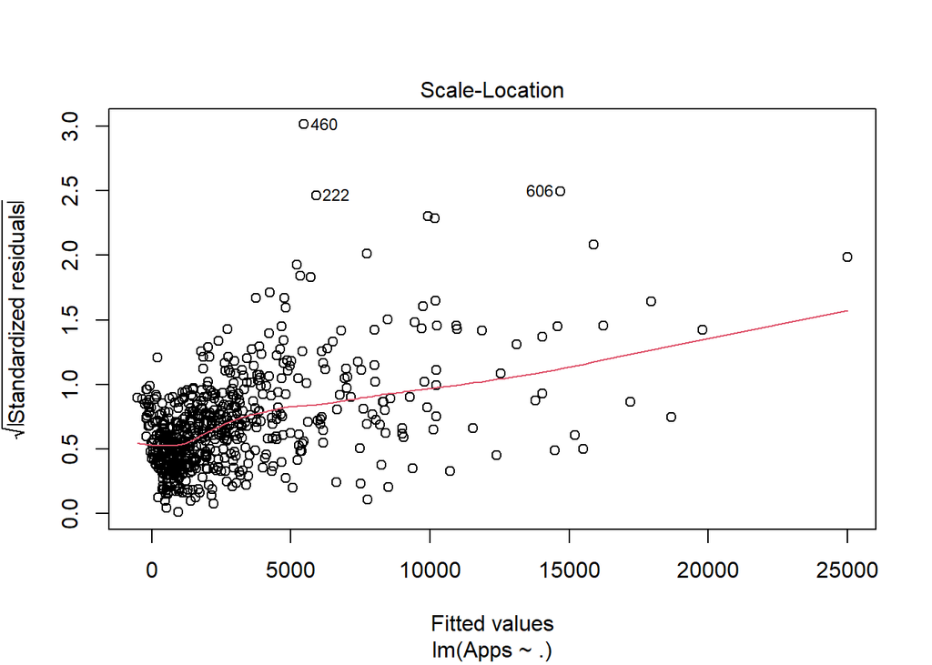

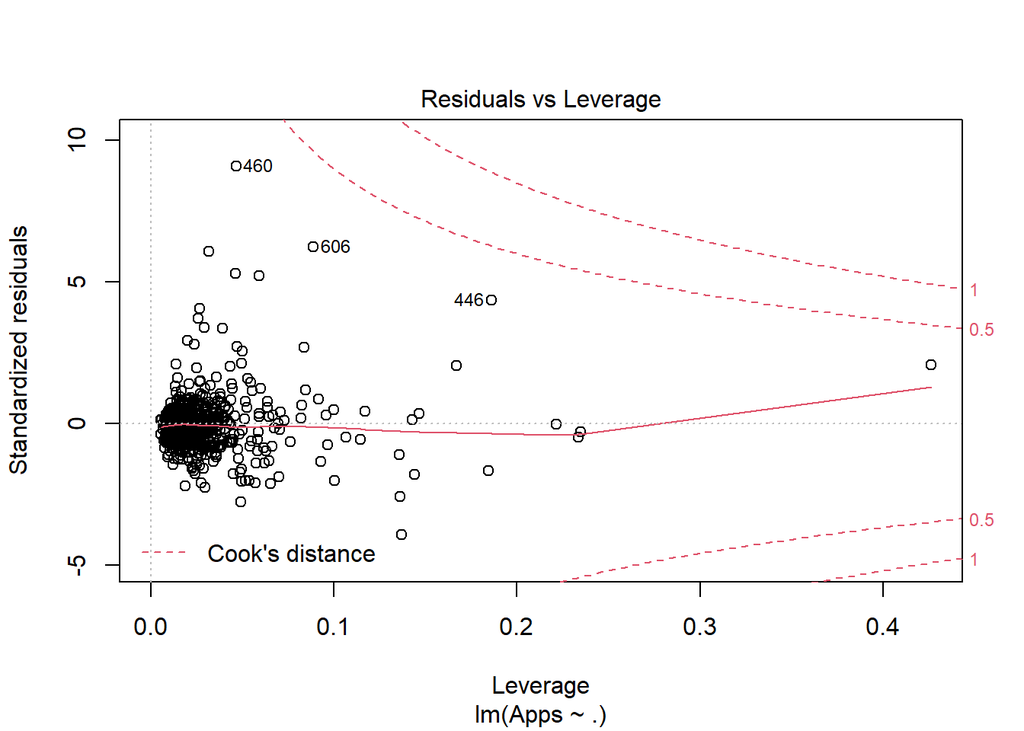

```r
plot(mAllRemoved)
```

**Note**: R-squared and Adjusted R-squared are improved and they are not that much different from each other, and from cook distance is fine. But we have Heteroscedasticity issue, we are not able to trust T test anymore.

#### Prediction Model 1-1 All feature

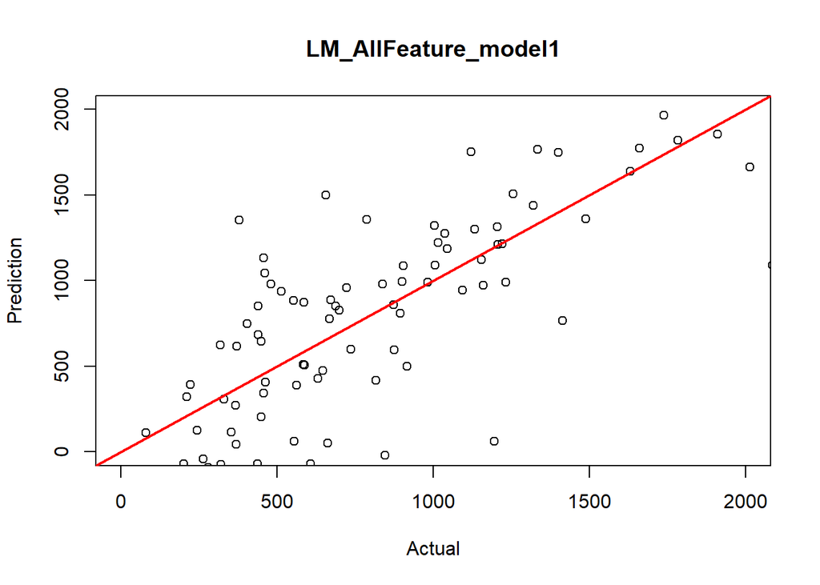

```r
pred_mAll <- predict(mAllRemoved, test)

#Absolute error mean, median, sd, max, min
abs_err_lm <- abs(pred_mAll - test$Apps)

#Create a dataframe to save prediction results on test data set
models_comp <- data.frame("RMSE"   =rmse(test$Apps, pred_mAll),
                          "Mean of AbsErrors"   = mean(abs_err_lm),
                          "Median of AbsErrors" = median(abs_err_lm),
                          "SD of AbsErrors"  = sd(abs_err_lm),
                          "IQR of AbsErrors" = IQR(abs_err_lm),
                          "Min of AbsErrors" = min(abs_err_lm),
                          "Max of AbsErrors" = max(abs_err_lm),
                          row.names = 'LM_AllFeature_model1')
#Actual vs. Predicted
plot(test$Apps, pred_mAll, main = 'LM_AllFeature_model1',
     xlim = c(0, 2000), ylim = c(0, 2000),
     xlab = "Actual", ylab = "Prediction")
abline(a = 0, b = 1, col = "red", lwd = 2)
```

#### Model 1-2 based on T test

```r
mTtest <-lm(Apps  ~ Private+ Accept +Top10perc  + Enroll + F.Undergrad + P.Undergrad
   +Outstate + Room.Board + PhD  + Expend + Grad.Rate, data = train2)
summary(mTtest)
```

```
##
## Call:
## lm(formula = Apps ~ Private + Accept + Top10perc + Enroll + F.Undergrad +
##     P.Undergrad + Outstate + Room.Board + PhD + Expend + Grad.Rate,
##     data = train2)
##
## Residuals:
##     Min      1Q  Median      3Q     Max
## -3240.0  -402.2   -25.7   291.6  7839.5
##
## Coefficients:
##               Estimate Std. Error t value Pr(>|t|)
## (Intercept) -638.41690  242.12852  -2.637 0.008587 **
## PrivateYes  -558.63128  128.81646  -4.337 1.69e-05 ***
## Accept         1.35315    0.04770  28.367  < 2e-16 ***
## Top10perc     30.60123    3.17127   9.650  < 2e-16 ***
## Enroll        -0.63317    0.17874  -3.542 0.000427 ***
## F.Undergrad    0.10126    0.02862   3.538 0.000434 ***
## P.Undergrad    0.05323    0.02994   1.778 0.075898 .
## Outstate      -0.05073    0.01731  -2.931 0.003510 **
## Room.Board     0.18159    0.04345   4.179 3.36e-05 ***
## PhD          -10.44940    2.91341  -3.587 0.000362 ***
## Expend         0.05260    0.01054   4.990 7.89e-07 ***
## Grad.Rate      7.25786    2.73517   2.654 0.008175 **
## ---
## Signif. codes:  0 '***' 0.001 '**' 0.01 '*' 0.05 '.' 0.1 ' ' 1
##
## Residual standard error: 874.8 on 605 degrees of freedom
## Multiple R-squared:  0.9372, Adjusted R-squared:  0.9361
## F-statistic: 821.1 on 11 and 605 DF,  p-value: < 2.2e-16
```

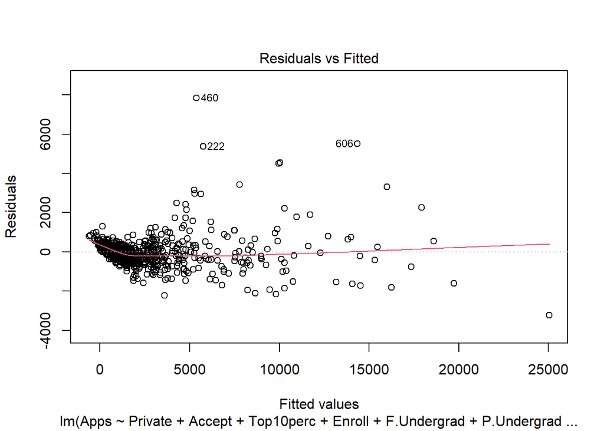

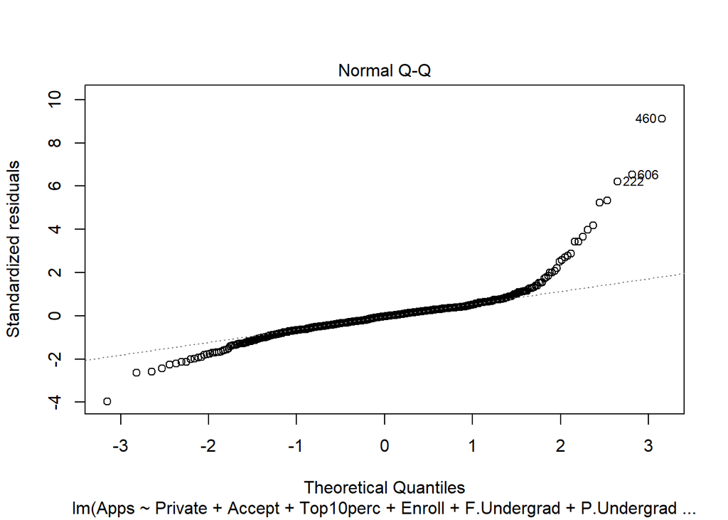

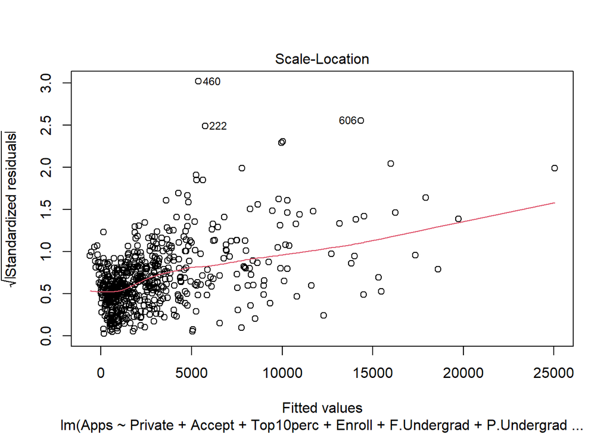

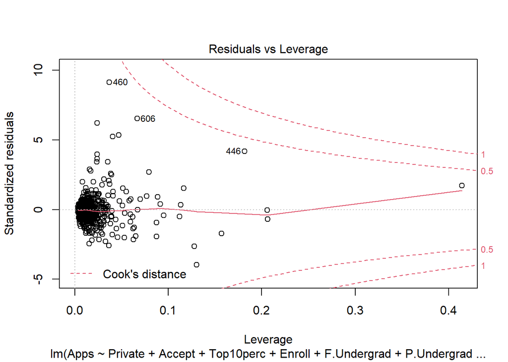

```r
plot(mTtest)
```

#### Prediction Model 1-2 based on T test

Right now we are developing models which has less feature and same accuracy

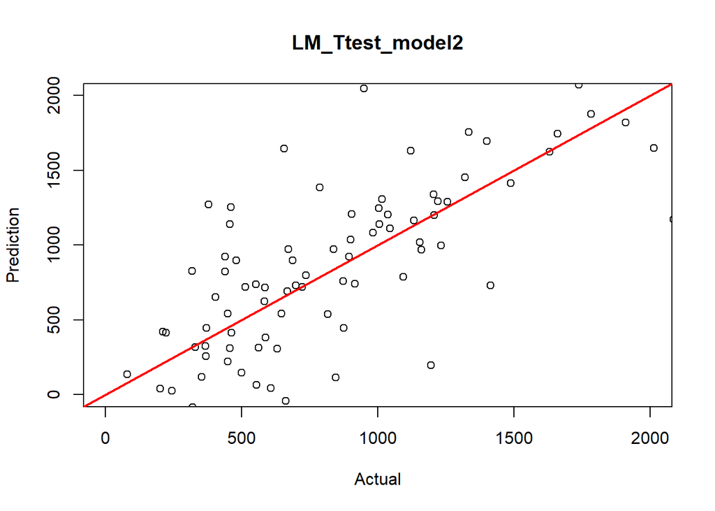

```r
pred_mTtest <- predict(mTtest, test)
#Absolute error mean, median, sd, max, min
abs_err_lm <- abs(pred_mTtest - test$Apps)

#Create a dataframe to save prediction results on test data set
models_comp <- rbind(models_comp, 'LM_Ttest_model2' = c(rmse(test$Apps, pred_mTtest),
                                                 mean(abs_err_lm),
                                                 median(abs_err_lm),
                                                 sd(abs_err_lm),
                                                 IQR(abs_err_lm),
                                                 range(abs_err_lm)))

#Actual vs. Predicted
plot(test$Apps, pred_mTtest, main = 'LM_Ttest_model2',
     xlim = c(0, 2000), ylim = c(0, 2000),
     xlab = "Actual", ylab = "Prediction")
abline(a = 0, b = 1, col = "red", lwd = 2)
```

**Note**: The accuracy of **model 1-1** is same as **model 1-2**. And we have used less feature. However still this model has some issue (Multidisciplinary and Heteroscedasticity)  
But my personal idea is **model1-2**, because we are using less feature and same accuracy.

### Model 2

#### Model 2-1 Best Subset Selection

```r
bestsub <- regsubsets(Apps ~ . , nvmax = 17, data = train2, method = "exhaustive")
summary(bestsub)$rsq
```

```
##  [1] 0.9034462 0.9260178 0.9282539 0.9309502 0.9323326 0.9338649 0.9347233
##  [8] 0.9356268 0.9363000 0.9368903 0.9373530 0.9376774 0.9379745 0.9380148
## [15] 0.9380240 0.9380273 0.9380295
```

Now I am going to take a look at **Adjusted_R**, and **CP**

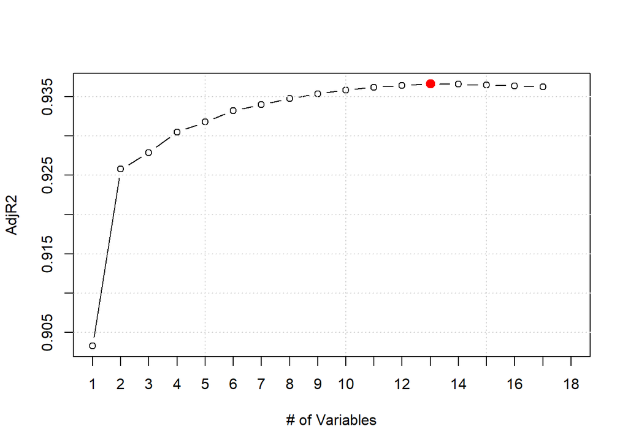

```r
#Plot Adjusted R-squared  --> 13
plot(summary(bestsub)$adjr2,
     type = "b",
     xlab = "# of Variables",
     ylab = "AdjR2",
     xaxt = 'n',
     xlim = c(1, 18)); grid()
axis(1, at = 1: 18, labels = 1: 18)

points(which.max(summary(bestsub)$adjr2),
       summary(bestsub)$adjr2[which.max(summary(bestsub)$adjr2)],
       col = "red", cex = 2, pch = 20)
```

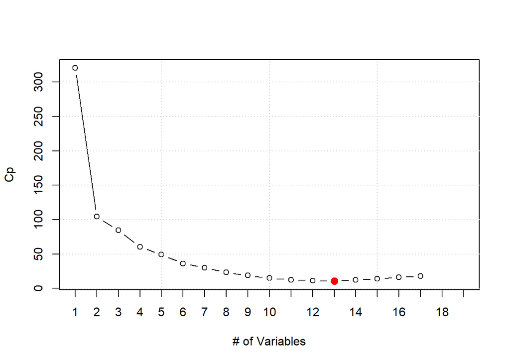

```r
#Plot Cp --> 13
plot(summary(bestsub)$cp,
     type = "b",
     xlab = "# of Variables",
     ylab = "Cp",
     xaxt = 'n',
     xlim = c(1, 19)); grid()
axis(1, at = 1: 19, labels = 1: 19)
points(which.min(summary(bestsub)$cp),
       summary(bestsub)$cp[which.min(summary(bestsub)$cp)],
       col = "red", cex = 2, pch = 20)
```

```r
#Coefficients of the best model
coef(bestsub, 13)
```

```
##   (Intercept)    PrivateYes        Accept        Enroll     Top10perc
## -501.11317516 -551.35462184    1.33666174   -0.60610046   38.65530462
##     Top25perc   F.Undergrad   P.Undergrad      Outstate    Room.Board
##   -7.24170865    0.10289901    0.05068116   -0.03917343    0.16637020
##           PhD   perc.alumni        Expend     Grad.Rate
##   -9.49304473   -7.55957711    0.04909153    9.26747198
```

We will continue this model with **Adjusted_R** assumption.

```r
bestsub2_Adj <- lm(Apps  ~ Accept + Top10perc + Top25perc+ Private + Enroll +
                    Outstate + Room.Board + PhD  + Expend + Grad.Rate +
                    F.Undergrad + P.Undergrad + S.F.Ratio + perc.alumni, data = train2)
summary(bestsub2_Adj)
```

```
##
## Call:
## lm(formula = Apps ~ Accept + Top10perc + Top25perc + Private +
##     Enroll + Outstate + Room.Board + PhD + Expend + Grad.Rate +
##     F.Undergrad + P.Undergrad + S.F.Ratio + perc.alumni, data = train2)
##
## Residuals:
##     Min      1Q  Median      3Q     Max
## -3181.7  -402.5   -38.7   309.2  7747.2
##
## Coefficients:
##               Estimate Std. Error t value Pr(>|t|)
## (Intercept) -571.94277  346.57619  -1.650 0.099410 .
## Accept         1.33617    0.04872  27.424  < 2e-16 ***
## Top10perc     38.61812    5.18443   7.449 3.28e-13 ***
## Top25perc     -7.23779    4.13640  -1.750 0.080666 .
## PrivateYes  -544.84102  130.26481  -4.183 3.31e-05 ***
## Enroll        -0.60396    0.18018  -3.352 0.000853 ***
## Outstate      -0.03876    0.01805  -2.148 0.032137 *
## Room.Board     0.16647    0.04392   3.790 0.000166 ***
## PhD           -9.53112    2.93509  -3.247 0.001230 **
## Expend         0.05040    0.01156   4.361 1.52e-05 ***
## Grad.Rate      9.25543    2.84138   3.257 0.001188 **
## F.Undergrad    0.10244    0.02867   3.573 0.000381 ***
## P.Undergrad    0.05071    0.02984   1.699 0.089772 .
## S.F.Ratio      3.68642   12.28961   0.300 0.764309
## perc.alumni   -7.46571    3.91437  -1.907 0.056963 .
## ---
## Signif. codes:  0 '***' 0.001 '**' 0.01 '*' 0.05 '.' 0.1 ' ' 1
##
## Residual standard error: 871.6 on 602 degrees of freedom
## Multiple R-squared:  0.938,  Adjusted R-squared:  0.9365
## F-statistic: 650.4 on 14 and 602 DF,  p-value: < 2.2e-16
```

#### PredictionModel 2-1 Best Subset Selection

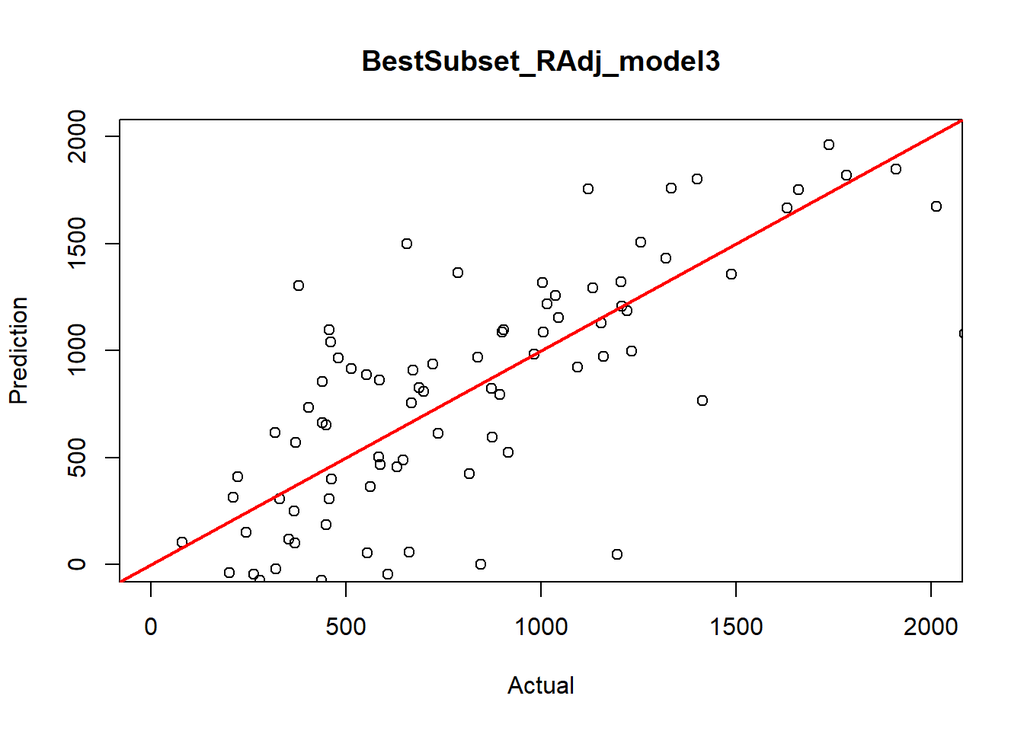

```r
pred_bestsubAdj  <- predict(bestsub2_Adj, test)

#Absolute error mean, median, sd, max, min
abs_err_bestsub <- abs(pred_bestsubAdj  - test$Apps )
abs_err_lm <- abs(pred_mTtest - test$Apps)
models_comp <- rbind(models_comp, 'BestSubset_RAdj_model3' = c(rmse(test$Apps, pred_bestsubAdj),
                                                        mean(abs_err_bestsub),
                                                        median(abs_err_bestsub),
                                                        sd(abs_err_bestsub),
                                                        IQR(abs_err_bestsub),
                                                        range(abs_err_bestsub)))

#Actual vs. Predicted
plot(test$Apps, pred_bestsubAdj, main = 'BestSubset_RAdj_model3',
     xlim = c(0, 2000), ylim = c(0, 2000),
     xlab = "Actual", ylab = "Prediction")
abline(a = 0, b = 1, col = "red", lwd = 2)
```

In here we can see model has improved a little

#### Model 2-2 Forward Selection and backward

```r
fwd_1 <- regsubsets(Apps ~ . , nvmax = 17, data = train2, method = "forward")


which.max(summary(fwd_1)$adjr2)
```

```
## [1] 13
```

```r
which.min(summary(fwd_1)$cp)
```

```
## [1] 13
```

```r
which.min(summary(fwd_1)$bic)
```

```
## [1] 7
```

```r
bwd_1 <- regsubsets(Apps ~ . , nvmax = 17, data = train2, method = "backward")


which.max(summary(bwd_1)$adjr2)
```

```
## [1] 13
```

```r
which.min(summary(bwd_1)$cp)
```

```
## [1] 13
```

```r
which.min(summary(bwd_1)$bic)
```

```
## [1] 9
```

**Note**: in the general **adjR** and **Cp** for backward and forward told us to use 13 variable on other hand **bic** told us 7 for forward and 9 for backward. But I will go for using **Cross Validation** incited of them.

#### Model 2-3 Using Cross validation

As mentioned above, the recommended model from **backward**, **forward** would be same as **Bestsubst**. However, they are faster than **Bestsubset**. So, we want to use **CV** methods. And in this method we will choose 11 variable.

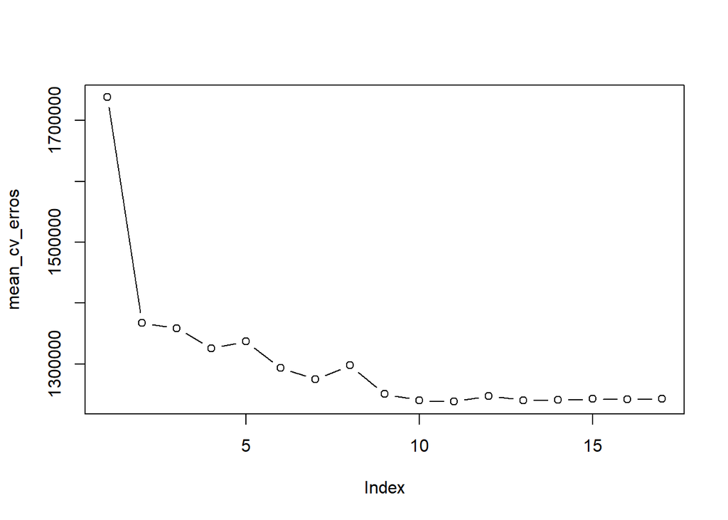

```r
k <- 10
set.seed(123)
folds <- sample(1: k, nrow(train), rep = TRUE)
cv_errors <- matrix(NA, k, 17, dimnames = list(NULL , paste(1: 17)))

predict_regsubsets <- function(object, newdata, id) {
  reg_formula <- as.formula(object$call[[2]])
  mat    <- model.matrix(reg_formula, newdata)
  coef_i <- coef(object, id = id)
  mat[, names(coef_i)] %*% coef_i
}

set.seed(1234)

for(i in 1: 17){
  for(j in 1: k){
    best_fit <- regsubsets(Apps ~ . , data = train2[folds != j,], nvmax = 17, method = "exhaustive")
    pred <- predict_regsubsets(best_fit, newdata = train[folds == j,], id = i)
    cv_errors[j, i] <- mean((train$Apps[folds == j] - pred) ^ 2)
  }
}
mean_cv_erros <- apply(cv_errors, 2, mean)

plot(mean_cv_erros, type = "b")
```

Selected Variable:

```r
coef(bestsub, which.min(mean_cv_erros))
```

```
##   (Intercept)    PrivateYes        Accept        Enroll     Top10perc
## -628.54260508 -558.64537132    1.32297280   -0.56752670   30.64312746
##   F.Undergrad      Outstate    Room.Board           PhD   perc.alumni
##    0.10805901   -0.04055908    0.17779931   -9.68756291   -8.24500810
##        Expend     Grad.Rate
##    0.05357717    8.07756899
```

```r
bestsub_cv <- lm(Apps ~ Private + Accept + Enroll + Top10perc +
                   F.Undergrad + Outstate + Room.Board + PhD +
                   perc.alumni + Expend + Grad.Rate, data = train2)
summary(bestsub_cv)
```

```
##
## Call:
## lm(formula = Apps ~ Private + Accept + Enroll + Top10perc + F.Undergrad +
##     Outstate + Room.Board + PhD + perc.alumni + Expend + Grad.Rate,
##     data = train2)
##
## Residuals:
##     Min      1Q  Median      3Q     Max
## -3120.0  -411.6   -42.0   292.7  7875.7
##
## Coefficients:
##               Estimate Std. Error t value Pr(>|t|)
## (Intercept) -628.54261  241.79920  -2.599 0.009565 **
## PrivateYes  -558.64537  128.63946  -4.343 1.65e-05 ***
## Accept         1.32297    0.04846  27.298  < 2e-16 ***
## Enroll        -0.56753    0.17981  -3.156 0.001678 **
## Top10perc     30.64313    3.15849   9.702  < 2e-16 ***
## F.Undergrad    0.10806    0.02811   3.844 0.000134 ***
## Outstate      -0.04056    0.01803  -2.249 0.024843 *
## Room.Board     0.17780    0.04352   4.085 5.00e-05 ***
## PhD           -9.68756    2.89872  -3.342 0.000883 ***
## perc.alumni   -8.24501    3.90023  -2.114 0.034926 *
## Expend         0.05358    0.01052   5.095 4.67e-07 ***
## Grad.Rate      8.07757    2.80299   2.882 0.004095 **
## ---
## Signif. codes:  0 '***' 0.001 '**' 0.01 '*' 0.05 '.' 0.1 ' ' 1
##
## Residual standard error: 873.9 on 605 degrees of freedom
## Multiple R-squared:  0.9374, Adjusted R-squared:  0.9362
## F-statistic: 822.9 on 11 and 605 DF,  p-value: < 2.2e-16
```

**Note**: R-squared has not changed a lot, but this model we do not have those issue which we had it before.

#### Prediction Model 2-3 Using Cross validation

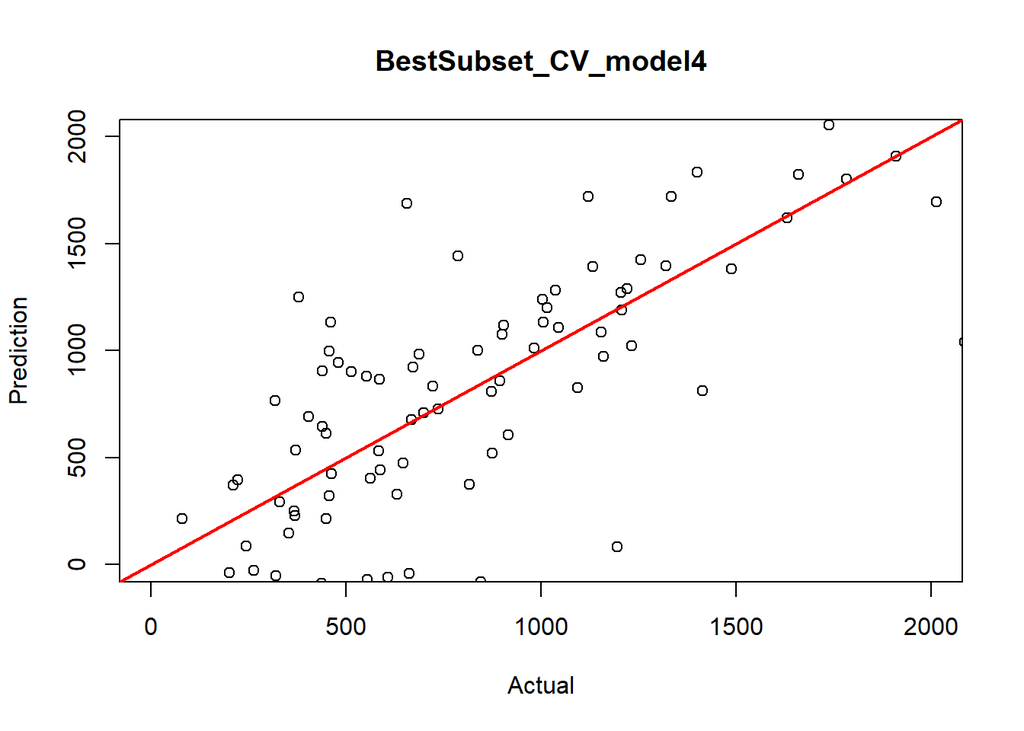

```r
pred_bestsub_cv <- predict(bestsub_cv, test)

##Absolute error mean, median, sd, max, min
abs_err_bestsub_cv <- abs(pred_bestsub_cv - test$Apps)
models_comp <- rbind(models_comp, 'BestSubset_CV_model4' = c(rmse(test$Apps, pred_bestsub_cv),
                                                      mean(abs_err_bestsub_cv),
                                                      median(abs_err_bestsub_cv),
                                                      sd(abs_err_bestsub_cv),
                                                      IQR(abs_err_bestsub_cv),
                                                      range(abs_err_bestsub_cv)))

## Actual vs. Predicted
plot(test$Apps, pred_bestsub_cv, main = 'BestSubset_CV_model4',
     xlim = c(0, 2000), ylim = c(0, 2000),
     xlab = "Actual", ylab = "Prediction")
abline(a = 0, b = 1, col = "red", lwd = 2)
```

### Model 3 Using Regularization

Here were are going to use Regularization (Ridge Regression and LASSO)

#### Model 3-1 Ridge Regression

```r
x <- model.matrix(Apps ~ . , data = train2)[, -1] #remove intercept
y <- train2$Apps
set.seed(1234)
lambda_grid <- 10 ^ seq(5, -2, length = 100) # we can change more grid and each time focus more to find better
ridge_cv    <- cv.glmnet(x, y, alpha = 0, lambda = lambda_grid, nfolds = 10)

## Coefficients of regression w/ best_lambda, Do not need to assign grid because we know the best lambda
ridgereg <- glmnet(x, y, alpha = 0, lambda = ridge_cv$lambda.min, standardize = TRUE, intercept = TRUE)
coef(ridgereg)
```

```
## 18 x 1 sparse Matrix of class "dgCMatrix"
##                        s0
## (Intercept) -553.89259691
## PrivateYes  -557.76375569
## Accept         1.28893736
## Enroll        -0.46041860
## Top10perc     36.87967437
## Top25perc     -6.09006373
## F.Undergrad    0.09749924
## P.Undergrad    0.04872796
## Outstate      -0.03362650
## Room.Board     0.17606609
## Books         -0.03629920
## Personal      -0.01098087
## PhD           -7.52934806
## Terminal      -2.95360650
## S.F.Ratio      3.94246427
## perc.alumni   -8.20970267
## Expend         0.05147881
## Grad.Rate      9.41523070
```

#### Prediction Model 3-1 Ridge Regression

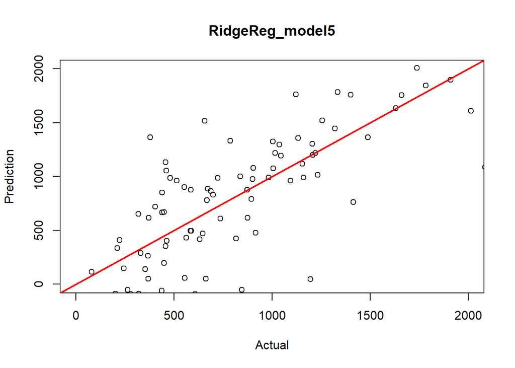

```r
x_test <- model.matrix(Apps ~ . , data = test)[, -1]#remove intercept
pred_ridgereg <- predict(ridgereg, s = ridge_cv$lambda.min, newx = x_test)

#Absolute error mean, median, sd, max, min-------
abs_err_ridgereg <- abs(pred_ridgereg - test$Apps)
models_comp <- rbind(models_comp, "RidgeReg_model5" = c(rmse(test$Apps, pred_ridgereg),
                                                 mean(abs_err_ridgereg),
                                                 median(abs_err_ridgereg),
                                                 sd(abs_err_ridgereg),
                                                 IQR(abs_err_ridgereg),
                                                 range(abs_err_ridgereg)))


#Actual vs. Predicted
plot(test$Apps, pred_ridgereg, main = 'RidgeReg_model5',
     xlim = c(0, 2000), ylim = c(0, 2000),
     xlab = "Actual", ylab = "Prediction")

abline(a = 0, b = 1, col = "red", lwd = 2)
```

#### Model 3-2 LASSO

```r
## Cross validation to choose the best model
lasso_cv    <- cv.glmnet(x, y, alpha = 1, lambda = lambda_grid, nfolds = 10)

## Coefficients of regression w/ best_lambda
lassoreg_2 <- glmnet(x, y, alpha = 1, lambda = lasso_cv$lambda.min, standardize = TRUE, intercept = TRUE)
coef(lassoreg_2)
```

```
## 18 x 1 sparse Matrix of class "dgCMatrix"
##                        s0
## (Intercept) -5.079748e+02
## PrivateYes  -5.518946e+02
## Accept       1.322219e+00
## Enroll      -5.426597e-01
## Top10perc    3.749860e+01
## Top25perc   -6.310940e+00
## F.Undergrad  9.794173e-02
## P.Undergrad  4.966767e-02
## Outstate    -3.627919e-02
## Room.Board   1.706571e-01
## Books       -2.727732e-02
## Personal    -6.896198e-03
## PhD         -7.580581e+00
## Terminal    -2.807416e+00
## S.F.Ratio    3.274392e+00
## perc.alumni -7.572796e+00
## Expend       5.062888e-02
## Grad.Rate    9.048809e+00
```

#### Prediction Model 3-2 LASSO

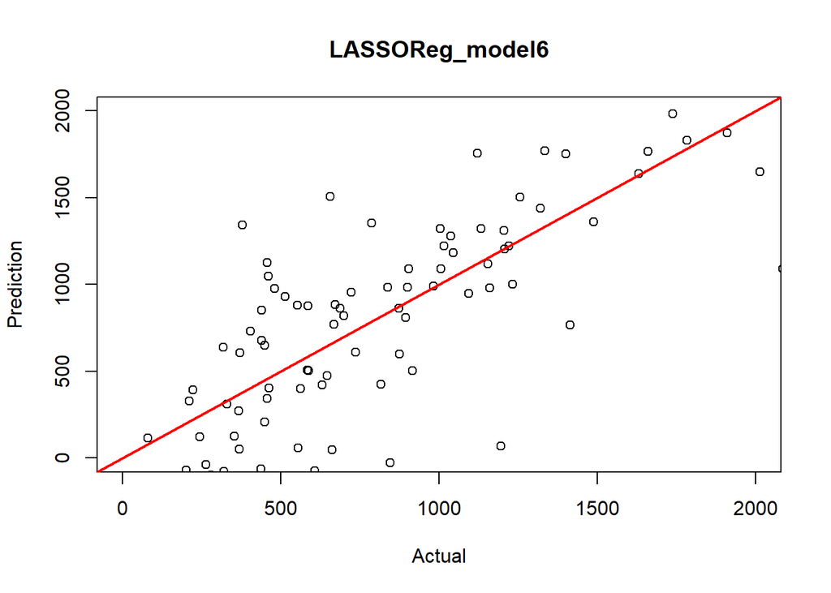

```r
x_test <- model.matrix(Apps ~ . , data = test)[, -1]#remove intercept
pred_lassoreg <- predict(lassoreg_2, s = lasso_cv$lambda.min, newx = x_test)

abs_err_lassoreg <- abs(pred_lassoreg - test$Apps)
models_comp <- rbind(models_comp, "LASSOReg_model6" = c(rmse(test$Apps, pred_lassoreg),
                                                 mean(abs_err_lassoreg),
                                                 median(abs_err_lassoreg),
                                                 sd(abs_err_lassoreg),
                                                 IQR(abs_err_lassoreg),
                                                 range(abs_err_lassoreg)))

#Actual vs. Predicted
plot(test$Apps, pred_lassoreg, main = 'LASSOReg_model6',
     xlim = c(0, 2000), ylim = c(0, 2000),
     xlab = "Actual", ylab = "Prediction")
abline(a = 0, b = 1, col = "red", lwd = 2)
```

```r
knitr::kable(
  models_comp , caption = 'Comparing models.'
)
```

Comparing models.

|  | RMSE | Mean.of.AbsErrors | Median.of.AbsErrors | SD.of.AbsErrors | IQR.of.AbsErrors | Min.of.AbsErrors | Max.of.AbsErrors |
| --- | --- | --- | --- | --- | --- | --- | --- |
| LM_AllFeature_model1 | 973.2118 | 582.5972 | 314.9756 | 782.0758 | 546.9115 | 3.3152656 | 5923.688 |
| LM_Ttest_model2 | 976.4392 | 575.7099 | 303.3804 | 791.2044 | 568.8033 | 3.3776476 | 6057.296 |
| BestSubset_RAdj_model3 | 972.9671 | 580.6685 | 311.0475 | 783.2122 | 564.2475 | 1.6338568 | 5933.761 |
| BestSubset_CV_model4 | 978.1606 | 584.3787 | 316.1097 | 786.9367 | 537.1093 | 1.7441864 | 6035.741 |
| RidgeReg_model5 | 975.0719 | 584.5706 | 320.6875 | 782.9251 | 576.6574 | 0.2851734 | 5922.923 |
| LASSOReg_model6 | 973.4585 | 582.0816 | 319.3540 | 782.7709 | 559.1354 | 3.4287591 | 5930.840 |

**Note:** we can see most of error still are staying in the same range. But **BestSubset_RAdj_model3** has better condition than other, However, we have to try non-linear models and Trees.